# Assignment 10: Predictive Modeling - Part 1

*Submission*: Submit the link on Github of the assignment to Canvas

1. Install the package `mlbench` and use the follows to import the data

```r
library(mlbench)
data(PimaIndiansDiabetes)
df <- PimaIndiansDiabetes
```

- Set seed to be 2020.
- The target variable is `diabetes`
- Partition the data into 80% training and 20% testing.

```r
head(df)
```

```
##   pregnant glucose pressure triceps insulin mass pedigree age diabetes
## 1        6     148       72      35       0 33.6    0.627  50      pos
## 2        1      85       66      29       0 26.6    0.351  31      neg
## 3        8     183       64       0       0 23.3    0.672  32      pos
## 4        1      89       66      23      94 28.1    0.167  21      neg
## 5        0     137       40      35     168 43.1    2.288  33      pos
## 6        5     116       74       0       0 25.6    0.201  30      neg
```

```r
names(df)[9] <- 'target'

library(caret)
set.seed(2020)
splitIndex <- createDataPartition(df$target, p = .80,
                                  list = FALSE)
df_train <- df[ splitIndex,]
df_test <- df[-splitIndex,]
```

2. Practice Decision Tree. Do the follows:
- Use `rpart` package, create a decision tree with maximum depth of 3.

```r
library(rpart)
tree_model <- rpart(target ~ ., data = df_train,
                 control = rpart.control(maxdepth = 3))
```

- Calculate the accuracy of the model on the testing data.

```r
#predict on testing data
pred <- predict(tree_model, df_test, type = "class")
#Evaluate the predictions
cm <- confusionMatrix(data = pred, reference = df_test$target, positive = "pos")
cm$overall[1]
```

```
##  Accuracy
## 0.7254902
```

- Plot the tree

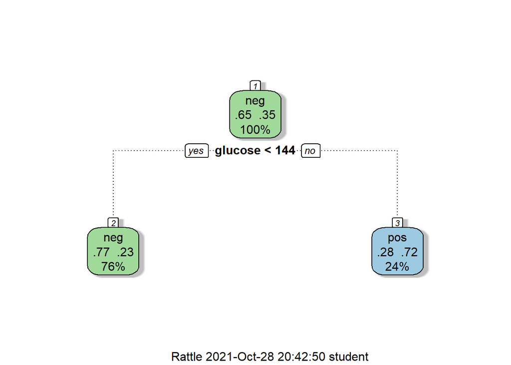

```r
library(rattle)
fancyRpartPlot(tree_model)
```

- Plot the variable importance by the tree

```r
tree_model$variable.importance
```

```
##   glucose   insulin  pressure  pedigree
## 53.233124  6.241125  1.101375  0.734250
```

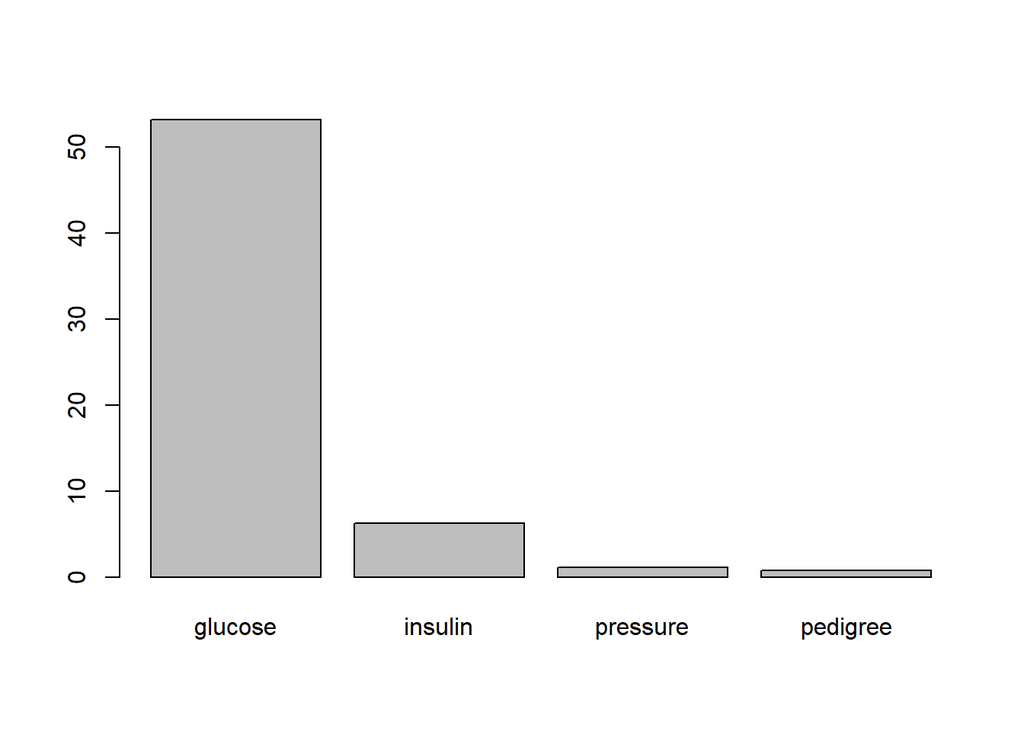

```r
barplot(tree_model$variable.importance)
```

3. Practice Random Forest. Do the follows:
- Use `randomForest` package, create a random forest of 1000 trees.

```r
library(randomForest)
forest_model = randomForest(target ~ ., data=df_train, ntree = 1000)
```

- Calculate the accuracy of the model on the testing data.

```r
pred <- predict(forest_model, df_test, method = "rf")
cm <- confusionMatrix(data = pred, reference = df_test$target, positive = "pos")
cm$overall[1]
```

```
##  Accuracy
## 0.7908497
```

- Plot the variable importance by the forest

```r
varImp(forest_model)
```

```
##           Overall
## pregnant 22.90061
## glucose  74.01213
## pressure 24.65639
## triceps  19.37641
## insulin  20.69518
## mass     44.06675
## pedigree 34.78747
## age      37.35174
```

4. Compare the testing accuracy of a forest of 1000 trees and a forest of 2000 trees.

```r
model1000 = randomForest(target ~ ., data=df_train, ntree = 1000)
pred <- predict(model1000, df_test, type = "class")
cm1 <- confusionMatrix(data = pred, reference = df_test$target, positive = "pos")
cm1$overall[1]
```

```
##  Accuracy
## 0.7777778
```

```r
model2000 = randomForest(target ~ ., data=df_train, ntree = 2000)
pred <- predict(model2000, df_test, type = "class")
cm2 <- confusionMatrix(data = pred, reference = df_test$target, positive = "pos")
cm2$overall[1]
```

```
##  Accuracy
## 0.7973856
```

5. Using Caret, create a tree with maximum depth of 3 and forest of 1000 trees. Compare the accuracy of these two models.

```r
model1 <- train(target~., data=df_train,
                method = "rpart2",
                maxdepth=3)
pred <- predict(model1, df_test)
cm <- confusionMatrix(data = pred, reference = df_test$target, positive = "pos")
cm$overall[1]
```

```
##  Accuracy
## 0.7647059
```

```r
model2 <- train(target~., data=df_train,
                method = "rf",
                ntree = 1000)
pred <- predict(model2, df_test)
cm <- confusionMatrix(data = pred, reference = df_test$target, positive = "pos")
cm$overall[1]
```

```
##  Accuracy
## 0.7843137
```

6. Plot variable importance by the two models in 5.

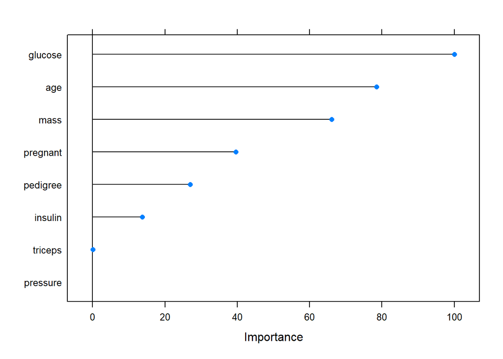

```r
plot(varImp(model1))
```

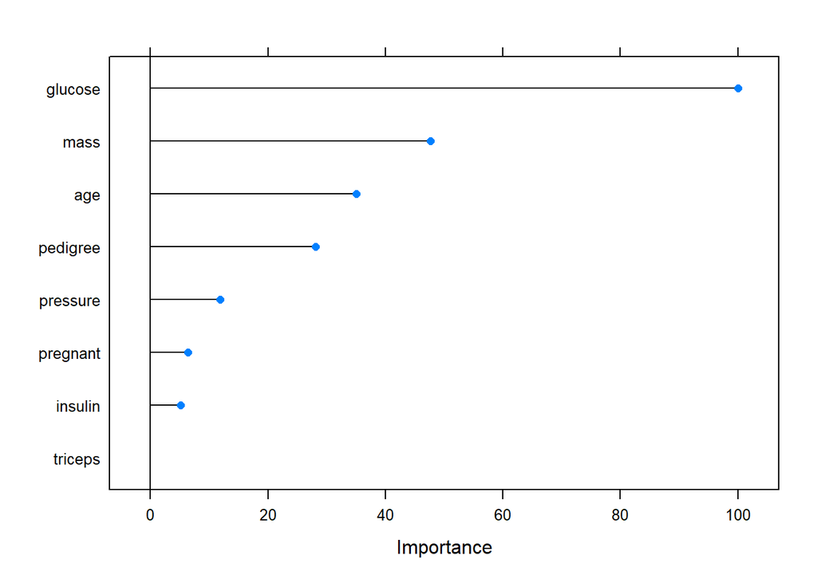

```r
plot(varImp(model2))
```

7. (Optional - For extra credits only) Use your own selected data. Do the follows.
- Handle missing values if any
- Put the variables in the right format (categorical vs. continuous)
- Select a binary target variable (Use can create a binary target variable from a continuous variable).
- Using caret with method `ranger` to train then test the accuracy of a random forest of 1000 trees.